# Disciplina - DQF10441 Física Experimental II"

## Aula em 23/07/2021 - Semestre 2021/1 EARTE

### [DQF - CCENS](http://alegre.ufes.br/ccens/departamento-de-quimica-e-fisica) - [UFES/Alegre](http://alegre.ufes.br/)

#### Professor : [Roberto Colistete Jr.](https://github.com/rcolistete)

# TAREFA PASSADA

Tarefa passada na aula anterior, individual ou 2 alunas/os ou em grupo (se estiver formado) :

- **experimentar ao menos 1 dos 3 softwares de desenho/projeto de circuitos eletrônicos (EDA)** citados ([Fritzing](https://fritzing.org/download/), [KiCAD](https://www.kicad.org/) e [EasyEDA](https://easyeda.com/));
- montar um circuito simples com fonte de tensão e um circuito com 3 resistores : 1 em série com 2 outros em paralelo;
- opinar sobre facilidade ou dificuldade de usar o software escolhido.

Alguém fez ? Mostre o que fez ou sabe fazer.

R.:

# Softwares de Simulação de Circuitos Elétricos/Eletrônicos

Foram apresentados nas aulas anteriores as seguintes web-apps (acessíveis via navegador web, sem precisar instalar no computador), de simulação de circuitos eletrônicos :

- [Falstad](https://www.falstad.com/circuit/circuitjs.html);
- [CircuitLab](https://www.circuitlab.com/);
- [PartSim](https://www.partsim.com/);

e esse software offline, para instalar em computador :

- [LTSpice](https://www.analog.com/en/design-center/design-tools-and-calculators/ltspice-simulator.html).

### Importante !

Parte desses softwares de simulação também podem ser utilizados para criar desenhos de circuitos eletrônicos (mas sem fazer diagramação em placa de circuito impresso), são digamos EDA's simplificados, por terem simbologia padrão de componentes eletrônicos.

# Experimentos

- Cronograma :
  - (30/07) 1o roteiro "Caracterização de dispositivos eletrônicos via multímetros";
  - (06/08) 2o roteiro, "Ligação série e paralelo";
  - (13/08) 3o roteiro, "Circuitos RC, carga e descarga de capacitor";
  - (20/08) 4o roteiro, "Filtros RC e espectro de sinal usando osciloscópio";
  - (03/09) 5o roteiro, "Medição de campo magnético";
  - (17/09) 6o roteiro, "Medição de luz e espectro luminoso".

## Experimento "Caracterização de dispositivos eletrônicos via multímetros"

Tal experimento é uma mistura dos experimentos originais :

- Instrumentação e grandezas elétricas;
- Caracterização de dispositivos elétricos e eletrônicos;

vide [sítio eletrônico do Laboratório 2 de Física da UFES-Alegre, seção de roteiros](https://fisica.alegre.ufes.br/roteiros-de-fisica-experimental-ii-e-fisica-iii).

Medidas que serão feitas :

- prática de multímetro com medições de tensão elétrica $V$, corrente elétrica $i$ e resistência elétrica $R$, variando as escalas possíveis, usando fonte de tensão simples;
- (curva de) caracterização $V \times i$ de 4 componentes eletrônicos (resistor, diodo, LED de uma cor, LED de outra cor), com 11 pares de medidas em cada componente, usando fonte de tensão simples;

### Teste

Vide Atividades no Google ClassRoom/Sala de Aula da disciplina.

É teste individual, no dia do experimento, durante a aula síncrona, às 18h15, duração de 10 minutos.

Feito usando Google Forms/Formulários.

### Pré-Relatório

Vide Atividades no Google ClassRoom/Sala de Aula da disciplina.

Pré-Relatório em grupo (3-4 alunos/as) sobre o experimento "Caracterização de dispositivos eletrônicos via multímetros".  
Data de entrega : 30/07/2021, até 17h59, antes do início da aula síncrona do experimento.

O conteúdo do pré-relatório envolve os 3 primeiros seções indicadas na apostila : https://fisica.alegre.ufes.br/sites/fisica.alegre.ufes.br/files/Apostila.Fis_.Exp1_.pdf pág. 42, "1.14 Elaboracão do Relatório: Partes Constituintes", mais seção final de bibliografia (presente no pré-relatório e relatório).

A seção "Procedimentos" deve também ter descrição sucinta de todos os componentes usados : fonte de tensão DC, multímetro, protoboard, resistor, diodo e LED.

### Relatório

Vide Atividades no Google ClassRoom/Sala de Aula da disciplina.

# Multímetros

[figure not shown]

## Lendo medidas de um Multímetro

Em parte das medidas usaremos o multímetro Minipa [ET-2042E](https://www.minipa.com.br/multimetros/multimetros-digitais/349-et-2042e)

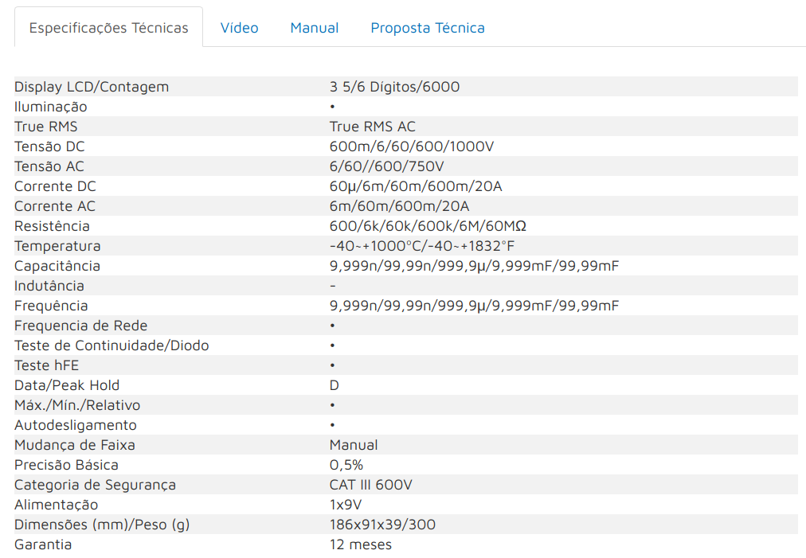

### Como ler medidas de tensão $V$ de um voltímetro (ou multímetro nesse modo)

Para medir :

- $V_{bat} = 1,5$ V (teórico);

qual escala do multímetro Minipa ET-2042E deve ser usada para ter menor erro em tal medida ?

R.: vide tabela B do manual do multímetro Minipa ET-2042E, **escala de 6V, que tem resolução de 0,001V e precisão de ±(0,5%+2D)**.

Se em tal escala foi medida a tensão (elétrica) de uma pilha recarregável :

$$V_{bat} = 1,329\,\text{V}$$

então calcule a incerteza da $V_{bat}$ medida, escrevendo a medida no formato (valor nominal +/- incerteza) com o número correto de algarismos significativos.

R.: $(1,329 \pm 0,009)$ V

```python
(1.329*0.005)+2*0.001
```

```
0.008645
```

### Como ler medidas de corrente elétrica $i$ de um amperímetro (ou multímetro nesse modo)

Para medir :

- $I_R = 12$ mA (teórico);

qual escala do multímetro Minipa ET-2042E deve ser usada para ter menor erro em tal medida ?

R.: vide tabela C do manual do multímetro Minipa ET-2042E, escala de 60 mA, que tem resolução de 0,01 mA e precisão de ±(0,8%+8D).

Se em tal escala foi medida a corrente (elétrica) :

$$I_{R} = 11,58\,\text{mA}$$

então calcule a incerteza da $I_R$, escrevendo a medida no formato (valor nominal +/- incerteza) com o número correto de algarismos significativos.

R.: $(11,58 \pm 0,17)$ mA

```python
(11.58*0.008)+8*0.01
```

```
0.17264000000000002
```

### Como ler medidas de resistência elétrica $R$ de um ohmímetro (ou multímetro nesse modo)

Para medir :

- $R = 4,7$ kOhm (valor nominal de um resistor);

qual escala do multímetro Minipa ET-2042E deve ser usada para ter menor erro em tal medida ?

Se em tal escala foi medida a resistência (elétrica) :

$$ R = 4,813\,\text{kOhm}$$

então calcule a incerteza de $R$, escrevendo a medida no formato (valor nominal +/- incerteza) com o número correto de algarismos significativos.

R.:

# Python + Uncertainties

Pratique calculando $P = V \times i$ da tabela da 4a questão do 1o trabalho. Fazer em grupo.

Mas use Uncertainties com arrays (NumPy), vide aula de 25/06/2021.

Motivação para usar arrays com incertezas :

1o relatório tem 88 cálculos de incertezas ao fazer caracterização $V \times i$ de 4 componentes, com 11 pares de medidas em cada um.